# Lecture 5

Rachel Ng

February 4, 2020

## Clustering

### K-means clustering algorithm

A. break observations into k pre-defined number of clusters B. define K the number of clusters! i. kmeans keep track of total variance and does whole thing over w/ different points ii. after many iterations, kmeans clustering knows best clustering so-far i.e. the one with smallest total variation with clusters C. in 2 dimension the Pythagoreum theorem is used D. in R: kmeans(x, centers = …, nstarts = …) i. Input x is a numeric matrix, or data.frame, with one observation per row, one feature per column ii. k-means has a random component iii. best outcome based on total w/i cluster sum of squares E. determining number of clusters i. systematically try a range of different K values and plot a ‘screen plot’

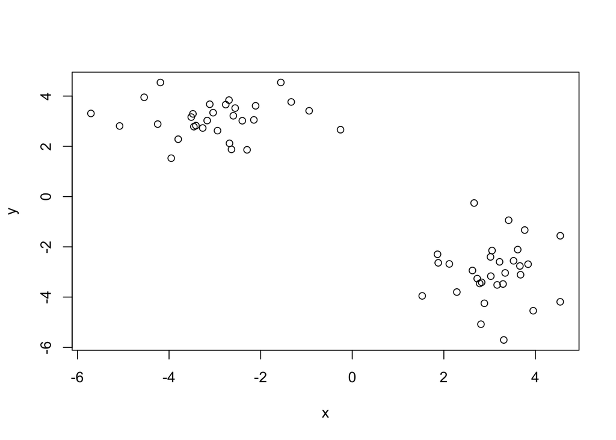

```r
#Generate some exapmle data for clustering
tmp <- c(rnorm(30,-3), rnorm(30,3))
x <- cbind(x=tmp, y=rev(tmp))

plot(x)
```

Use the kmeans() function setting k to 2 and nstart=20 Inspect/print the results Q. How many points are in each cluster? Q. What ‘component’ of your result object details - cluster size? - cluster assignment/membership? shown by clustering vector: which cluster each member is assigned to - cluster center?

```r
km <- kmeans(x, centers =2, nstart = 20)
print(km)
```

```
## K-means clustering with 2 clusters of sizes 30, 30
##
## Cluster means:
##           x         y
## 1 -2.995428  3.097474
## 2  3.097474 -2.995428
##
## Clustering vector:
##  [1] 1 1 1 1 1 1 1 1 1 1 1 1 1 1 1 1 1 1 1 1 1 1 1 1 1 1 1 1 1 1 2 2 2 2 2 2 2 2
## [39] 2 2 2 2 2 2 2 2 2 2 2 2 2 2 2 2 2 2 2 2 2 2
##
## Within cluster sum of squares by cluster:
## [1] 54.48433 54.48433
##  (between_SS / total_SS =  91.1 %)
##
## Available components:
##
## [1] "cluster"      "centers"      "totss"        "withinss"     "tot.withinss"
## [6] "betweenss"    "size"         "iter"         "ifault"
```

```r
#cluster size
km$cluster
```

```
##  [1] 1 1 1 1 1 1 1 1 1 1 1 1 1 1 1 1 1 1 1 1 1 1 1 1 1 1 1 1 1 1 2 2 2 2 2 2 2 2
## [39] 2 2 2 2 2 2 2 2 2 2 2 2 2 2 2 2 2 2 2 2 2 2
```

```r
#cluster length
length(km$cluster)
```

```
## [1] 60
```

```r
table(km$cluster)
```

```
##
##  1  2
## 30 30
```

Plot x colored by the kmeans cluster assignment and add cluster centers as blue points

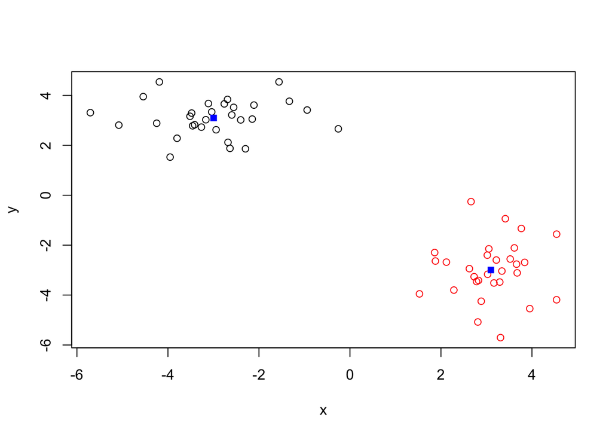

```r
plot(x, col=km$cluster)
points(km$centers, col = "blue", pch = 15)
```

### Hierarchial clustering

A. simple: each point starts as its own clsuter B. important: calculate point (dis)similarity as Euclidean distance b/w observations before calling C. lots more utility than kmeans, but have to spell out what you would like to do

The main Hclustering fucniton in R is called `hclust()`

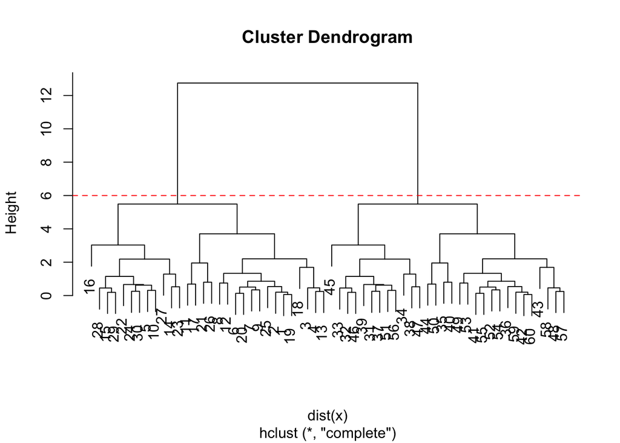

```r
dist_matrix <- dist(x)
hc <- hclust(dist(x))

#plotting dendrogram
plot(hc)
abline(h=6, col = "red", lty = 2)
```

To get cluster membership vector I need to “cut” the tree at a certain height to yield my seprate cluster branches

```r
cutree(hc, h = 6)
```

```
##  [1] 1 1 1 1 1 1 1 1 1 1 1 1 1 1 1 1 1 1 1 1 1 1 1 1 1 1 1 1 1 1 2 2 2 2 2 2 2 2
## [39] 2 2 2 2 2 2 2 2 2 2 2 2 2 2 2 2 2 2 2 2 2 2
```

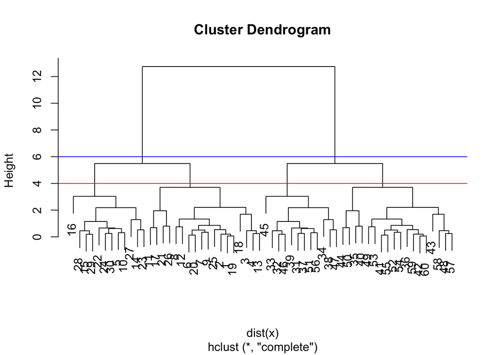

```r
plot(hc)
abline(h=6, col = "blue")
abline(h=4, col = "red")
```

```r
cutree(hc, h = 4)
```

```
##  [1] 1 1 1 1 2 1 1 1 1 2 1 1 1 2 2 2 1 1 1 1 1 2 2 2 1 1 2 2 2 2 3 3 3 3 4 4 3 3
## [39] 3 4 4 4 4 4 3 3 3 4 4 4 3 4 4 4 4 3 4 4 4 4
```

Example 2:

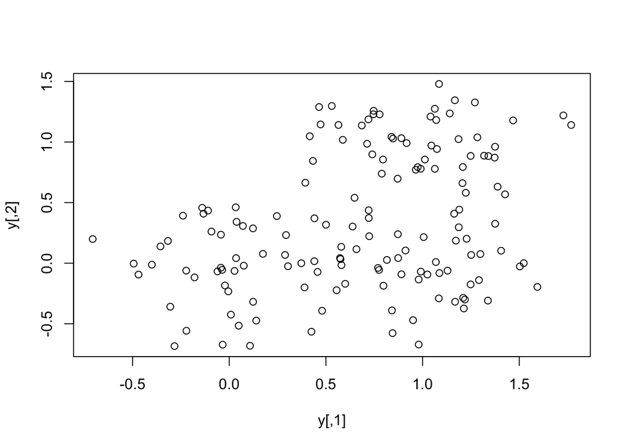

```r
#Step 1. Generate data
y <- rbind(
 matrix(rnorm(100, mean=0, sd = 0.3), ncol = 2), # c1
 matrix(rnorm(100, mean = 1, sd = 0.3), ncol = 2), # c2
 matrix(c(rnorm(50, mean = 1, sd = 0.3), # c3
 rnorm(50, mean = 0, sd = 0.3)), ncol = 2))
colnames(x) <- c("x", "y")

# Step 2. Plot the data without clustering
plot(y)
```

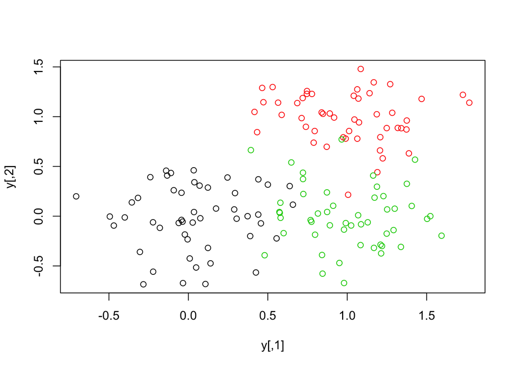

```r
# Step 3. Generate colors for known clusters
# (just so we can compare to hclust results)
col <- as.factor( rep(c("c1","c2","c3"), each=50) )
plot(y, col=col)
```

Use the dist(), hclust(), plot() and cutree() functions to return 2 and 3 clusters Q. How does this compare to your known ‘col’ groups?

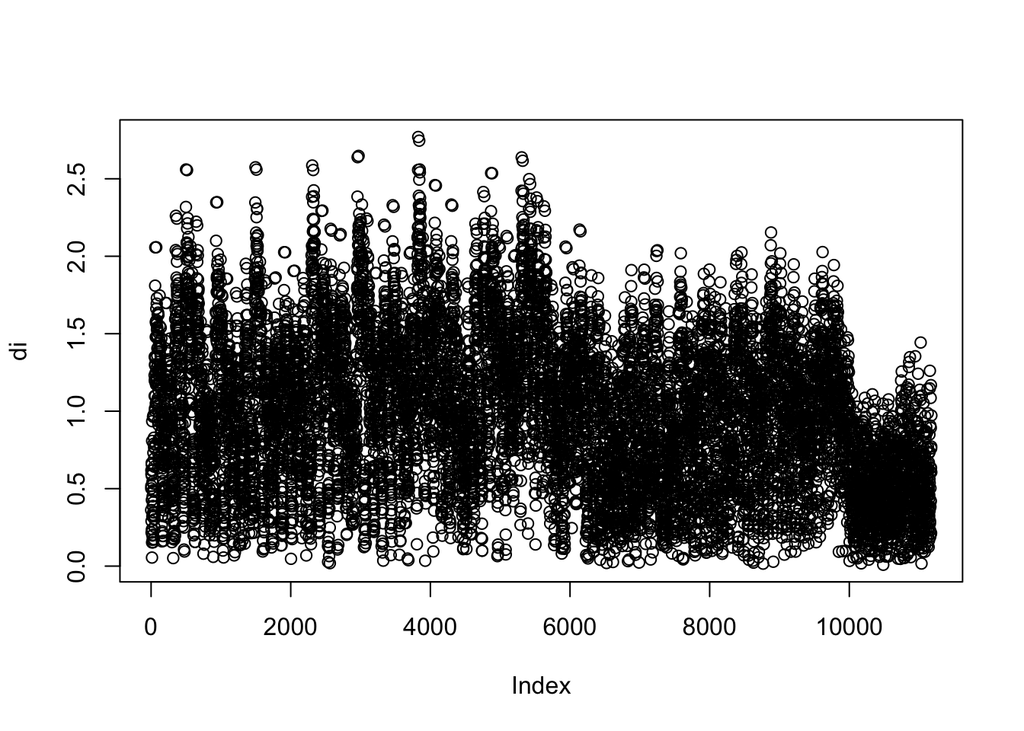

```r
di <- dist(y)
plot(di)
```

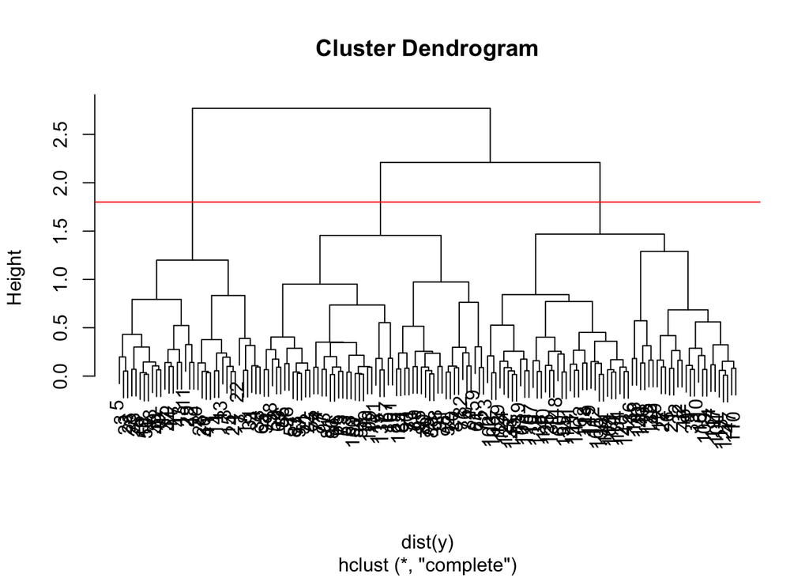

```r
hc <- hclust(dist(y))
plot(hc)
abline(h = 1.8, col = "red")
```

```r
#to get cluster membership vector use `cutree()`
#to tabulate how many members in each cluster we have use `table()`
grps <- cutree(hc, k=3)
table(grps)
```

```
## grps
##  1  2  3
## 35 61 54
```

### Dimensionality reduciton, visualization, and structure analysis